# R Notebook

Week 11 Day 4

Text Analysis

```r
library(tidyverse)
library(tidytext)
```

| id | phrase |
| --- | --- |
| 1 | here is some text |
| 2 | again more text |
| 3 | text is text |

| id | word |
| --- | --- |
| 1 | here |
| 1 | is |
| 1 | some |
| 1 | text |
| 2 | again |
| 2 | more |
| 2 | text |
| 3 | text |
| 3 | is |
| 3 | text |

```r
phrases <- c(
  "Here is some text.",
  "Again, more text!",
  "TEXT is text?"
)
```

```r
example_text <- tibble(id = seq(phrases), phrase = phrases)
```

| id | word |
| --- | --- |
| 1 | here |
| 1 | is |
| 1 | some |
| 1 | text |
| 2 | again |
| 2 | more |
| 2 | text |
| 3 | text |
| 3 | is |
| 3 | text |

| id | word |
| --- | --- |
| 1 | Here |
| 1 | is |
| 1 | some |
| 1 | text |
| 1 | . |
| 2 | Again |
| 2 | , |
| 2 | more |
| 2 | text |
| 2 | ! |

[output cut: 4 more lines]

Task

```r
lines <-
c(
  "Whose woods these are I think I know.",
  "His house is in the village though;",
  "He will not see me stopping here",
  "To watch his woods fill up with snow."
)
```

Task

Create a DF, one with each word and the line number of the word

```r
lines_text <- tibble(id = seq(lines),
                     line = lines)
lines_text

unnested_lines <- lines_text %>%
  unnest_tokens(word, line)
```

| word | n |
| --- | --- |
| his | 2 |
| i | 2 |
| woods | 2 |
| are | 1 |
| fill | 1 |
| he | 1 |
| here | 1 |
| house | 1 |
| in | 1 |
| is | 1 |

[output cut: 17 more lines]

function created ???

```r
tibble(line_no = seq(lines), line = lines) %>%
  unnest_tokens(word, line)

create_text_df <- function(text) {
  tibble(line_no = seq(text), line = text) %>%
    unnest_tokens(output = word, input = line)
}
create_text_df
```

```r
head(prideprejudice, 20)
```

```
 [1] "PRIDE AND PREJUDICE"
 [2] ""
 [3] "By Jane Austen"
 [4] ""
 [5] ""
 [6] ""
 [7] "Chapter 1"
 [8] ""
 [9] ""
[10] "It is a truth universally acknowledged, that a single man in possession"
[11] "of a good fortune, must be in want of a wife."
[12] ""
[13] "However little known the feelings or views of such a man may be on his"
[14] "first entering a neighbourhood, this truth is so well fixed in the minds"
[15] "of the surrounding families, that he is considered the rightful property"
[16] "of some one or other of their daughters."
[17] ""
[18] "\"My dear Mr. Bennet,\" said his lady to him one day, \"have you heard that"
[19] "Netherfield Park is let at last?\""
[20] ""
```

Making the prideprejudice into a df

| line_no | word |
| --- | --- |
| 1 | pride |
| 1 | and |
| 1 | prejudice |
| 3 | by |
| 3 | jane |
| 3 | austen |
| 7 | chapter |
| 7 | 1 |
| 10 | it |
| 10 | is |

[output cut: 990 more lines]

Stop word dictionary

```r
pride_book %>%
  anti_join(stop_words) %>%
  count(word, sort = TRUE)
```

| word | n |
| --- | --- |
| elizabeth | 597 |
| darcy | 373 |
| bennet | 294 |
| miss | 283 |
| jane | 264 |
| bingley | 257 |
| time | 203 |
| lady | 183 |
| sister | 180 |
| wickham | 162 |

[output cut: 990 more lines]

```r
pride_book
```

Task do the same thing for sense and sensibility

```r
sense_book <- create_text_df(sensesensibility)
```

```r
sense_book %>%
  anti_join(stop_words) %>%
  count(word, sort = TRUE) %>%
  slice(1:5)
```

| word | n |
| --- | --- |
| elinor | 623 |
| marianne | 492 |
| time | 239 |
| dashwood | 231 |
| sister | 229 |

https://1drv.ms/u/s!ApAHmNS-ofL2kzpCQrQvIZCtFUzT?e=iUZDcf

** LUNCH BREAK **

Comparing word frequencies across dataframes

## TF IDF

term frequency - inverse document frequency

```r
library(tidytext)

unnest_tokens(token = )
```

```r
sentences <- c(
  "This is a sentence about cats.",
  "This is a sentence about dogs.",
  "This is a sentence about alligators."
)
```

```r
unnest_tokens(word, sentence)
```

```
Error in UseMethod("pull") :
  no applicable method for 'pull' applied to an object of class "function"
```

| word | id | n | tf | idf | tf_idf |
| --- | --- | --- | --- | --- | --- |
| a | 1 | 1 | 0.1666667 | 0.000000 | 0.000000 |
| a | 2 | 1 | 0.1666667 | 0.000000 | 0.000000 |
| a | 3 | 1 | 0.1666667 | 0.000000 | 0.000000 |
| about | 1 | 1 | 0.1666667 | 0.000000 | 0.000000 |
| about | 2 | 1 | 0.1666667 | 0.000000 | 0.000000 |
| about | 3 | 1 | 0.1666667 | 0.000000 | 0.000000 |
| alligators | 3 | 1 | 0.1666667 | 1.098612 | 0.183102 |
| cats | 1 | 1 | 0.1666667 | 1.098612 | 0.183102 |
| dogs | 2 | 1 | 0.1666667 | 1.098612 | 0.183102 |
| is | 1 | 1 | 0.1666667 | 0.000000 | 0.000000 |

[output cut: 8 more lines]

**TF** = Term Frequency will be high for important words(in a doc)

**DF** = document frequency will be low if it is in few documents

**TF-IDF** = Term Frequency - Inverse Document Frequency is a measure of how important a word is to a document in a collection of documents

doing this across jane austens books

```r
titles <- c("Pride and Prejudice", "Sense and Sensibility", "Emma", "Persuasion", "Mansfield Park", "Northanger Abbey")

books <- list(prideprejudice, sensesensibility, emma, persuasion, mansfieldpark,  northangerabbey)
```

```r
all_books <- purrr::map_chr(books, paste, collapse = " ")
```

| title | word |
| --- | --- |
| Pride and Prejudice | pride |
| Pride and Prejudice | and |
| Pride and Prejudice | prejudice |
| Pride and Prejudice | by |
| Pride and Prejudice | jane |
| Pride and Prejudice | austen |

| word | title | n | tf | idf | tf_idf |
| --- | --- | --- | --- | --- | --- |
| elinor | Sense and Sensibility | 623 | 5.193528e-03 | 1.7917595 | 9.305552e-03 |
| marianne | Sense and Sensibility | 492 | 4.101470e-03 | 1.7917595 | 7.348847e-03 |
| crawford | Mansfield Park | 493 | 3.072417e-03 | 1.7917595 | 5.505032e-03 |
| darcy | Pride and Prejudice | 373 | 3.052273e-03 | 1.7917595 | 5.468939e-03 |
| elliot | Persuasion | 254 | 3.036171e-03 | 1.7917595 | 5.440088e-03 |
| emma | Emma | 786 | 4.882109e-03 | 1.0986123 | 5.363545e-03 |
| tilney | Northanger Abbey | 196 | 2.519928e-03 | 1.7917595 | 4.515105e-03 |
| weston | Emma | 389 | 2.416209e-03 | 1.7917595 | 4.329266e-03 |
| bennet | Pride and Prejudice | 294 | 2.405813e-03 | 1.7917595 | 4.310639e-03 |
| wentworth | Persuasion | 191 | 2.283105e-03 | 1.7917595 | 4.090775e-03 |

[output cut: 990 more lines]

```r
all_books_tf_idf %>%
  group_by(title) %>%
  slice_max(tf_idf)
```

## Lesson 3

N-grams

bigrams = words of two (e.g. “the who”, “may the”, “the queen”)

trigrams = words of three (e.g. “may the force”)

```r
phrases <- c(
  "here is some text",
  "again more text",
  "text is text"
)

phrases_df <- tibble(
  phrase = phrases,
  id     = 1:3
)


phrases_df %>%
  unnest_tokens(bigram, phrase, token = "ngrams", n = 2)
```

For the book P&P, find the top bigrams and trigrams

```r
book_df <- tibble(
  id = 1:length(prideprejudice),
  text = prideprejudice
)

book_df %>%
  unnest_tokens(bigram, text, token = "ngrams", n = 2) %>%
  count(bigram, sort = TRUE)
```

```r
book_df %>%
  unnest_tokens(trigram, text, token = "ngrams", n = 3) %>%
  count(trigram, sort = TRUE)
```

```r
book_df %>%
  unnest_tokens(character, text, token = "characters") %>%
  count(character, sort = TRUE)
```

| bigram | word1 | word2 | n |
| --- | --- | --- | --- |
| NA NA | NA | NA | 2556 |
| lady catherine | lady | catherine | 87 |
| miss bingley | miss | bingley | 67 |
| miss bennet | miss | bennet | 52 |
| sir william | sir | william | 35 |
| de bourgh | de | bourgh | 32 |
| miss darcy | miss | darcy | 32 |
| cried elizabeth | cried | elizabeth | 24 |
| colonel forster | colonel | forster | 23 |
| miss lucas | miss | lucas | 23 |

[output cut: 990 more lines]

Main functions to remember from this

bind_tf_idf() unnest_tokens(df, bigram, phrase, token = “ngrams”, n = 2)

## Sentiment analysis

sentiment dictionaries

| sentiment | n |
| --- | --- |
| anger | 1246 |
| anticipation | 837 |
| disgust | 1056 |
| fear | 1474 |
| joy | 687 |
| negative | 3318 |
| positive | 2308 |
| sadness | 1187 |
| surprise | 532 |
| trust | 1230 |

| sentence | word |
| --- | --- |
| 1 | pride |
| 1 | prejudice |
| 3 | jane |
| 3 | austen |
| 7 | chapter |
| 7 | 1 |
| 10 | truth |
| 10 | universally |
| 10 | acknowledged |
| 10 | single |

[output cut: 990 more lines]

```r
book_pride %>%
  left_join(get_sentiments("bing"))
```

| sentence | word | sentiment |
| --- | --- | --- |
| 1 | pride | positive |
| 1 | prejudice | negative |
| 3 | jane | NA |
| 3 | austen | NA |
| 7 | chapter | NA |
| 7 | 1 | NA |
| 10 | truth | NA |
| 10 | universally | NA |
| 10 | acknowledged | NA |
| 10 | single | NA |

[output cut: 990 more lines]

```r
book_sentiments <- book_pride %>%
  inner_join(get_sentiments("bing"))
```

```r
book_pride %>%
  inner_join(get_sentiments("loughran"))
```

| sentence | word | sentiment |
| --- | --- | --- |
| 1 | prejudice | negative |
| 1 | prejudice | litigious |
| 30 | objection | negative |
| 37 | delighted | positive |
| 75 | assure | positive |
| 80 | impossible | negative |
| 84 | assure | positive |
| 85 | consent | litigious |
| 96 | abuse | negative |
| 97 | delight | positive |

[output cut: 990 more lines]

| word | n |
| --- | --- |
| love | 92 |
| pleasure | 92 |
| happy | 83 |
| happiness | 72 |
| affection | 58 |
| regard | 49 |
| pride | 48 |
| perfectly | 47 |
| agreeable | 45 |
| civility | 42 |

[output cut: 559 more lines]

| word | n |
| --- | --- |
| love | 92 |
| pleasure | 92 |
| happy | 83 |
| happiness | 72 |
| affection | 58 |
| regard | 49 |
| pride | 48 |
| perfectly | 47 |
| agreeable | 45 |
| civility | 42 |

[output cut: 559 more lines]

| word | n |
| --- | --- |
| miss | 283 |
| object | 48 |
| scarcely | 45 |
| impossible | 44 |
| poor | 38 |
| afraid | 37 |
| doubt | 37 |
| lost | 29 |
| pain | 28 |
| absence | 27 |

[output cut: 825 more lines]

| sentence | mean_sentiment |
| --- | --- |
| 18 | 2.0000000 |
| 28 | -2.0000000 |
| 34 | 2.0000000 |
| 37 | 2.0000000 |
| 47 | 2.0000000 |
| 48 | 2.0000000 |
| 52 | 2.0000000 |
| 57 | -2.0000000 |
| 58 | 3.0000000 |
| 66 | 1.5000000 |

[output cut: 990 more lines]

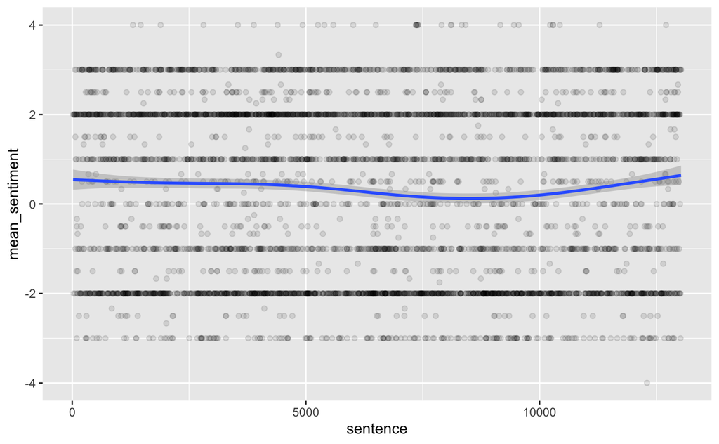

```r
ggplot(sentence_sentiments, aes(sentence, mean_sentiment)) +
  geom_point(alpha = 0.1) +
  geom_smooth()
```